# JavaScript Fundamentals

## Introduction to JavaScript

JavaScript was created in 1995 by Brendan Eich while he was working at Netscape. It was originally called Mocha, then renamed to LiveScript, and finally to JavaScript. Today, JavaScript is one of the most popular programming languages in the world, primarily used for web development.

JavaScript consists of three main components:

- **ECMAScript**: The core language specification
- **DOM (Document Object Model)**: Allows JavaScript to interact with HTML and CSS
- **BOM (Browser Object Model)**: Allows JavaScript to interact with the browser

## Variables and Data Types

### Variable Basics

In JavaScript, variables are containers for storing data values. Here’s how to create and use them:

```javascript
// Declaring variables
let name = "John";         // Using let (recommended)
var age = 30;              // Using var (older style)
const PI = 3.14;           // Using const (for values that won't change)
```

Important rules for variables:

- Cannot start with digits or special characters (except $ and _)
- Use camelCase by convention (e.g., `firstName`, `totalAmount`)
- JavaScript is dynamically typed (you don’t need to specify the type)
- In contrast, languages like Java and C# are statically typed

### Data Types

JavaScript has two main categories of data types:

#### 1. Primitive Types

These are simple, immutable data types:

- **undefined**: A variable that has been declared but not assigned a value

  ```javascript
  let undeclaredVar;
  console.log(typeof undeclaredVar); // undefined
  ```

- **null**: Represents the intentional absence of any object value

  ```javascript
  let emptyValue = null;
  console.log(null == undefined); // true (loose equality)
  console.log(null === undefined); // false (strict equality)
  ```

- **NaN**: Stands for “Not a Number” - a special numeric value indicating an invalid number

  ```javascript
  console.log('a' / 2); // NaN
  console.log(NaN == NaN); // false (NaN doesn't equal anything, even itself)
  ```

- **string**: Text data (immutable in JavaScript)

  ```javascript
  let greeting = "Hello";
  // Strings in JavaScript are immutable - operations create new strings
  let newGreeting = greeting + " World"; // Creates a new string
  ```

- **boolean**: true or false values

  ```javascript
  let isActive = true;
  let isComplete = false;
  ```

- **symbol**: A unique and immutable primitive value

  ```javascript
  let s1 = Symbol(); // Creates a new unique value
  console.log(Symbol() == Symbol()); // false
  ```

- **bigint**: For representing large integers

  ```javascript
  let bigNumber = 123456789012345678901234567890n; // The 'n' suffix makes it a BigInt
  ```

#### 2. Complex Types

These are more complex data structures:

- **Object**: A collection of properties (key-value pairs)

  ```javascript
  let person = {
    name: "John",
    age: 25,
    isEmployed: true
  };

  // Accessing properties
  console.log(person.name);        // Using dot notation
  console.log(person["age"]);      // Using array notation

  // Adding/modifying properties
  person.location = "New York";

  // Deleting properties
  delete person.age;

  // Checking if a property exists
  console.log("name" in person);   // true
  ```

## Helpful Features

### Numeric Separator

For better readability of large numbers: It’s important to note that all numbers in JavaScript are floating-point numbers.

```javascript
let amount = 120_201_123.05; // Same as 120201123.05
let billion = 1_000_000_000;
let binary = 0b1010_1010;    // Binary
let hex = 0x1A_2B_3C;        // Hexadecimal
```

### Boolean Conversion

The `Boolean()` function converts values to boolean:

```javascript
// These convert to true
Boolean("Hello");    // Non-empty string
Boolean(42);         // Non-zero number
Boolean({});         // Any object

// These convert to false
Boolean("");         // Empty string
Boolean(0);          // Zero
Boolean(NaN);        // Not a Number
Boolean(null);       // Null
Boolean(undefined);  // Undefined
```

### String Features

#### Template Literals

```javascript
let name = "Sarah";
let greeting = `Hello, I'm ${name}!`; // String interpolation
```

#### String Access

```javascript
let word = "Hello";
console.log(word[0]);                 // "H" (first character)
console.log(word[word.length - 1]);   // "o" (last character)
```

#### String Conversion

```javascript
let num = 42;
let str1 = String(num);    // "42"
let str2 = num + "";       // "42"
let str3 = num.toString(); // "42" (doesn't work for undefined and null)
```

## Value Types vs Reference Types

Understanding how JavaScript stores and passes values is crucial:

### Primitive vs Reference Values

- Primitive values (like numbers, strings) are stored directly in memory (on the stack)
- Reference values (objects, arrays, functions) store a reference pointing to the actual data (on the heap)

When you assign or pass primitive values, JavaScript creates copies:

```javascript
let a = 5;
let b = a;  // 'b' gets a copy of the value
a = 10;     // Changing 'a' doesn't affect 'b'
console.log(b);  // Still 5
```

When you assign or pass objects, JavaScript copies the reference, not the actual data:

```javascript
let obj1 = {name: "John"};
let obj2 = obj1;           // Both variables reference the same object
obj1.name = "Mike";        // Changes affect both variables
console.log(obj2.name);    // "Mike"
```

This diagram helps visualize it:

| Stack (Fixed size) | Heap (Dynamic size) |
| --- | --- |
| Primitive values | Object data |
| References to objects → | ← Referenced by stack variables |

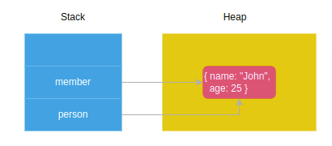

stackAndHeapInJs.png

## Arrays

Arrays are special objects used to store ordered collections:

```javascript
// Creating arrays
let colors = ["red", "green", "blue"];
let numbers = new Array(1, 2, 3);     // Using constructor
let emptyWithSize = new Array(5);     // Creates array with 5 empty slots

// Common array operations
colors.push("yellow");       // Add to end: ["red", "green", "blue", "yellow"]
colors.unshift("purple");    // Add to beginning: ["purple", "red", "green", "blue", "yellow"]
colors.pop();                // Remove from end: ["purple", "red", "green", "blue"]
colors.shift();              // Remove from beginning: ["red", "green", "blue"]
let position = colors.indexOf("green");  // Find index: 1
let isArray = Array.isArray(colors);     // Check if array: true
```

## Operators

### Arithmetic Operators

JavaScript handles type conversion automatically in arithmetic operations:

```javascript
console.log(5 + 2);    // 7
console.log("5" + 2);  // "52" (string concatenation)
console.log("5" - 2);  // 3 (string converted to number)
console.log("5" * 2);  // 10 (string converted to number)
```

### Value Conversion

Using the unary plus/minus to convert values:

```javascript
let str = "10";
console.log(+str);      // 10 (number)
console.log(-str);      // -10 (number)

console.log(+true);     // 1
console.log(+false);    // 0
```

### Increment/Decrement Operators

There are important differences between prefix and postfix:

```javascript
// Prefix (++x) - increments first, then uses the value
let a = 5;
let b = ++a;    // a = 6, b = 6

// Postfix (x++) - uses the original value, then increments
let c = 5;
let d = c++;    // c = 6, d = 5
```

## Control Flow Statements

JavaScript provides various ways to control program flow:

```javascript
// if statement
if (condition) {
  // code to execute if condition is true
} else if (anotherCondition) {
  // code to execute if anotherCondition is true
} else {
  // code to execute if no conditions are true
}

// Ternary operator
let result = condition ? valueIfTrue : valueIfFalse;

// Switch statement
switch (expression) {
  case value1:
    // code when expression equals value1
    break;
  case value2:
    // code when expression equals value2
    break;
  default:
    // code when no cases match
}

// Loops
for (let i = 0; i < 5; i++) {
  // repeats 5 times
}

while (condition) {
  // executes as long as condition is true
}

do {
  // executes at least once, then as long as condition is true
} while (condition);

// break exits the loop, continue skips to next iteration
```

# JavaScript Functions

## Basic Function Behavior

### Return Values

- Every function in JavaScript implicitly returns **undefined** unless you explicitly return another value

### The Arguments Object

- Inside a function, you can access an object called **arguments** that contains all arguments passed to the function
- The **arguments** object behaves like an array though it is not an instance of the Array type
- `arguments.length` shows the number of actual arguments passed to the function

```javascript
function add(x, y = 1, z = 2) {
    console.log(arguments.length);
    return x + y + z;
}

add(10);      // outputs: 1
add(10, 20);  // outputs: 2
add(10, 20, 30); // outputs: 3
```

## Hoisting

### Variable Hoisting

- **Var hoisting**: Variables declared with `var` are hoisted to the top of their scope and initialized with **undefined**
- **Let hoisting**: Variables declared with `let` are also hoisted but not initialized (creating a “temporal dead zone”)

```javascript
// With var
console.log(counter); // outputs: undefined
var counter = 1;

// With let
console.log(counter); // ReferenceError: Cannot access 'counter' before initialization
let counter = 1;
```

### Function Hoisting

- **Function declarations** are hoisted completely (both declaration and definition)
- **Function expressions**, **arrow functions**, and **class expressions** are NOT hoisted

```javascript
// This works - function declaration is hoisted
sayHello();
function sayHello() {
    console.log("Hello!");
}

// This fails - function expression is not hoisted
sayGoodbye(); // TypeError: sayGoodbye is not a function
var sayGoodbye = function() {
    console.log("Goodbye!");
};
```

## Parameters and Arguments

### Parameter Default Values

- In JavaScript, parameters have a default value of **undefined** if no argument is provided
- You can set explicit default values for parameters:

```javascript
function greet(name = "Guest") {
    return `Hello, ${name}!`;
}
greet();      // "Hello, Guest!"
greet("John"); // "Hello, John!"
```

### Passing Arguments

#### Primitives (Pass by Value)

- Primitive values (strings, numbers, booleans) are passed by value
- Changes to parameters inside the function do not affect the original variables

```javascript
function increment(x) {
    x += 1;
    console.log("Inside function:", x);
}

let num = 5;
increment(num); // Inside function: 6
console.log(num); // Still 5
```

#### Objects (Pass by Reference-like Behavior)

- Objects are passed by reference-like behavior
- Modifying object properties inside a function affects the original object
- However, reassigning the parameter to a new object does not affect the original reference

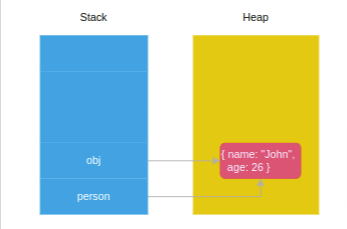

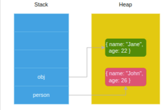

```javascript
let person = {
    name: "John",
    age: 25
};

function increaseAge(obj) {
    obj.age += 1;              // Modifies the original object
    obj = { name: "Jane", age: 22 }; // Local reassignment, doesn't affect original
}

increaseAge(person);
console.log(person); // { name: "John", age: 26 }
```

Another example:

```javascript
const styles = { color: "red" };

function change(styles) {
    styles = { background: "black" }; // Local reassignment, no effect on original
}

change(styles);
console.log(styles); // { color: 'red' }
```

### Named Parameters

- JavaScript doesn’t support true named parameters like some languages
- To skip parameters, you must use `undefined`:

```javascript
function createDiv(height, width, border) {
    // Function implementation
}

// To only set border, you must use:
createDiv(undefined, undefined, 'solid 5px blue');
```

#### Better Alternative: Object Parameters

- The most effective way to handle optional parameters is by using an object parameter:

```javascript
function createDiv(options = {}) {
    const {
        height = '100px',
        width = '100px',
        border = 'none'
    } = options;

    // Function implementation using height, width, border
}

// Call with only needed parameters
createDiv({ border: 'solid 5px blue' });
```

## First-Class Functions

- In JavaScript, functions are first-class citizens
- They can be:
  - Stored in variables
  - Passed as arguments to other functions
  - Returned from other functions
  - Stored in data structures like arrays and objects

```javascript
// Function stored in variable
const add = function(a, b) { return a + b; };

// Function passed as argument
[1, 2, 3].map(function(x) { return x * 2; });

// Function returned from another function
function createMultiplier(factor) {
    return function(x) {
        return x * factor;
    };
}
const double = createMultiplier(2);
console.log(double(5)); // 10
```

# JavaScript Objects & Prototypes

## Constructor Functions

Constructor functions are a way to create multiple objects with the same structure and behavior.

```javascript
function Person(firstName, lastName) {
    this.firstName = firstName;
    this.lastName = lastName;

    this.getFullName = function() {
        return this.firstName + " " + this.lastName;
    };
}

// Create a new Person object
let person = new Person("John", "Doe");
console.log(person.getFullName()); // "John Doe"
```

### Key Points About Constructor Functions:

1. **Naming Convention**: Constructor functions start with a capital letter (e.g., `Person`) to distinguish them from regular functions.
2. **The `new` Keyword**: When calling a constructor with `new`:
   - A new empty object is created
   - `this` is bound to that new object
   - The function code executes
   - The new object is returned automatically
3. **Memory Inefficiency Problem**: The original approach creates a new copy of methods like `getFullName()` for each instance, which wastes memory.

### Handling Constructor Calls Without `new`

If a constructor function is called without the `new` keyword, it executes as a regular function, and `this` refers to the global object (or `undefined` in strict mode):

```javascript
// Safeguard a constructor function
function Person(firstName, lastName) {
    // Check if called without new
    if (!new.target) {
        return new Person(firstName, lastName);
    }

    this.firstName = firstName;
    this.lastName = lastName;
}

// This still works correctly
let person = Person("John", "Doe");
console.log(person.firstName); // "John"
```

## Prototypes

Every JavaScript object has a special property called `prototype`, which enables objects to inherit features from one another.

### How Prototypes Work:

1. Every JavaScript function has a property called `prototype` (which is itself an object)
2. When you use a function as a constructor with `new`, the created object gets linked to the constructor’s `prototype`
3. When you try to access a property on an object:
   - First, JavaScript looks for the property on the object itself
   - If not found, it looks in the object’s prototype
   - If still not found, it looks in the prototype’s prototype, and so on (forming the “prototype chain”)
   - The chain ends when a prototype is `null`

### Using Prototypes for Method Sharing

Instead of defining methods inside the constructor (which creates copies), we can add them to the prototype:

```javascript
function Person(firstName, lastName) {
    this.firstName = firstName;
    this.lastName = lastName;
    // Notice: no methods defined here
}

// Add method to the prototype (shared by all instances)
Person.prototype.getFullName = function() {
    return this.firstName + " " + this.lastName;
};

let person1 = new Person("John", "Doe");
let person2 = new Person("Jane", "Smith");

console.log(person1.getFullName()); // "John Doe"
console.log(person2.getFullName()); // "Jane Smith"

// Both instances share the same method
console.log(person1.getFullName === person2.getFullName); // true
```

### Prototype Chain Relationships

Every constructor function’s prototype is linked to `Object.prototype`:

```javascript
// The constructor property points back to the function
console.log(Person.prototype.constructor === Person); // true

// Person's prototype is linked to Object.prototype
console.log(Object.getPrototypeOf(Person.prototype) === Object.prototype); // true

// Ways to access an object's prototype
let p = new Person("John", "Doe");
console.log(Person.prototype === Object.getPrototypeOf(p)); // true
console.log(Person.prototype === p.constructor.prototype); // true
```

## Prototypal Inheritance

In JavaScript, objects can inherit from other objects - this is called prototypal inheritance.

### Using `__proto__` (Legacy Method)

```javascript
let person = {
    name: "John Doe",
    greet: function() {
        return "Hi, I'm " + this.name;
    }
};

let teacher = {
    teach: function(subject) {
        return "I can teach " + subject;
    }
};

// Make teacher inherit from person
teacher.__proto__ = person;

console.log(teacher.greet()); // "Hi, I'm John Doe"
console.log(teacher.teach("JavaScript")); // "I can teach JavaScript"
```

### Modern Ways to Create Inheritance

**ES5 Method**:

```javascript
let person = {
    name: "John Doe",
    greet: function() {
        return "Hi, I'm " + this.name;
    }
};

// Create a new object with person as its prototype
let teacher = Object.create(person);
teacher.teach = function(subject) {
    return "I can teach " + subject;
};

console.log(Object.getPrototypeOf(teacher) === person); // true
```

**ES6 Method**:

```javascript
class Person {
    constructor(name) {
        this.name = name;
    }

    greet() {
        return "Hi, I'm " + this.name;
    }
}

class Teacher extends Person {
    constructor(name) {
        super(name);
    }

    teach(subject) {
        return "I can teach " + subject;
    }
}
```

## Object Properties

JavaScript objects have two types of properties:

1. **Data Properties**: Store values
2. **Accessor Properties**: Functions that get or set values (getters and setters)

### Property Attributes

Every property has attributes that control its behavior:

**Data Properties**:

- **Configurable**: If false, the property cannot be deleted or have its attributes changed
- **Enumerable**: If true, the property appears in for…in loops
- **Writable**: If false, the property’s value cannot be changed
- **Value**: The actual value of the property

**Accessor Properties**:

- **Configurable**: Same as above
- **Enumerable**: Same as above
- **Get**: The getter function
- **Set**: The setter function

### Defining Properties

You can define or modify property attributes using `Object.defineProperty()` or `Object.defineProperties()`:

```javascript
let product = {};

Object.defineProperties(product, {
    name: {
        value: 'Smartphone',
        enumerable: true  // Will show up in for...in loops
    },
    price: {
        value: 799,
        writable: true    // Can be changed
    },
    tax: {
        value: 0.1,
        configurable: false // Cannot be deleted
    },
    netPrice: {
        // Accessor property with getter
        get: function() {
            return this.price * (1 + this.tax);
        }
    }
});

console.log(product.name); // "Smartphone"
console.log(product.netPrice); // 878.9
```

### Property Enumeration and Ownership

- `for...in` loops iterate over all enumerable properties (including inherited ones)
- `obj.propertyIsEnumerable()` checks if a property is enumerable
- `obj.hasOwnProperty()` checks if a property belongs to the object itself (not inherited)

### Computed Properties (ES6)

Allow you to use expressions as property names:

```javascript
let propName = 'dynamicProperty';
let obj = {
    [propName]: 'value'  // Creates property named "dynamicProperty"
};

// Useful for creating objects dynamically
function createObj(key, value) {
    return { [key]: value };
}

let user = createObj('username', 'john_doe');
console.log(user); // { username: 'john_doe' }
```

## Classes (ES6)

ES6 introduced a cleaner syntax for creating objects and implementing inheritance:

```javascript
class Person {
  // Class properties
  #firstName;  // Private property (with # prefix)
  #lastName;   // Private property
  static count = 0;  // Static property (shared by all instances)

  // Constructor
  constructor(firstName, lastName) {
    this.#firstName = firstName;
    this.#lastName = lastName;
    Person.count++;  // Increment the counter
  }

  // Instance method
  getFullName() {
    return `${this.#firstName} ${this.#lastName}`;
  }

  // Private method
  #validateName(name) {
    return typeof name === 'string' && name.trim().length >= 2;
  }

  // Static method
  static createAnonymous() {
    return new Person("Anonymous", "User");
  }
}

// Create an instance
let person = new Person("John", "Doe");
console.log(person.getFullName());  // "John Doe"
console.log(Person.count);  // 1
```

### Inheritance with Classes

```javascript
class Employee extends Person {
  #position;

  constructor(firstName, lastName, position) {
    super(firstName, lastName);  // Call parent constructor
    this.#position = position;
  }

  getRole() {
    return this.#position;
  }

  // Override parent method
  getFullName() {
    return `${super.getFullName()} (${this.#position})`;
  }
}

let employee = new Employee("Jane", "Smith", "Developer");
console.log(employee.getFullName());  // "Jane Smith (Developer)"
```

# JavaScript Advanced Functions

## Functions as Objects

In JavaScript, all functions are actually objects - they are instances of the `Function` type. This means functions can:

- Have properties and methods
- Be passed as arguments to other functions
- Be assigned to variables
- Be returned from other functions

## Closures

A closure is a function that retains access to its lexical scope (variables from its parent function) even after the parent function has finished executing.

### How Closures Work

1. When you define a function inside another function, the inner function has access to the variables of the outer function
2. If the inner function is returned or otherwise preserved (like stored in a variable or passed as a callback), it maintains access to those variables
3. This preserved environment is called a closure

### Practical Example of Closure Issues

Consider this classic problem with loops and `setTimeout`:

```javascript
for (var index = 1; index <= 3; index++) {
    setTimeout(function () {
        console.log('after ' + index + ' second(s): ' + index);
    }, index * 1000);
}
// Output:
// after 4 second(s): 4
// after 4 second(s): 4
// after 4 second(s): 4
```

What happened? By the time the first callback executes (after 1000ms), the loop has already completed, and `index` is `4`. All three functions in the closure share the same `index` variable.

### Solutions to the Loop Closure Problem

#### Solution 1: IIFE (Immediately Invoked Function Expression)

Create a new scope for each iteration using an IIFE:

```javascript
for (var index = 1; index <= 3; index++) {
    (function(currentIndex) {
        setTimeout(function () {
            console.log('after ' + currentIndex + ' second(s): ' + currentIndex);
        }, currentIndex * 1000);
    })(index);
}
// Output:
// after 1 second(s): 1
// after 2 second(s): 2
// after 3 second(s): 3
```

#### Solution 2: Block Scoping with `let` (ES6+)

The `let` keyword creates a new binding for each loop iteration:

```javascript
for (let index = 1; index <= 3; index++) {
    setTimeout(function () {
        console.log('after ' + index + ' second(s): ' + index);
    }, index * 1000);
}
// Output:
// after 1 second(s): 1
// after 2 second(s): 2
// after 3 second(s): 3
```

## The `this` Keyword in Functions

The value of `this` inside a function depends on how the function is called, not where it’s defined.

### Common `this` Binding Issues

```javascript
function Car() {
  this.speed = 0;
  this.speedUp = function(speed) {
    this.speed = speed;
    setTimeout(function() {
      console.log(this.speed); // undefined
    }, 1000);
  };
}

let car = new Car();
car.speedUp(50);
```

Inside the `setTimeout` callback, `this` doesn’t refer to the Car instance. Instead, it refers to the global object (or `undefined` in strict mode).

### Solutions to the `this` Problem

#### Solution 1: Preserve `this` with a variable

```javascript
function Car() {
  this.speed = 0;
  this.speedUp = function(speed) {
    this.speed = speed;
    let self = this; // Store reference to 'this'
    setTimeout(function() {
      console.log(self.speed); // 50
    }, 1000);
  };
}
```

#### Solution 2: Use an arrow function (ES6+)

```javascript
function Car() {
  this.speed = 0;
  this.speedUp = function(speed) {
    this.speed = speed;
    setTimeout(() => {
      console.log(this.speed); // 50
    }, 1000);
  };
}
```

Arrow functions inherit `this` from their surrounding scope, which solves the problem elegantly.

## Arrow Functions

Arrow functions were introduced in ES6 and provide more concise syntax, plus they handle `this` differently.

### Syntax

```javascript
// Traditional function
function add(a, b) {
  return a + b;
}

// Arrow function
const add = (a, b) => a + b;
```

### Special Characteristics of Arrow Functions

1. **No `this` binding**
   - Arrow functions don’t have their own `this` - they inherit it from the parent scope
   - This makes them ideal for callbacks inside methods where you want to access the parent’s `this`
2. **No `arguments` object**
   - Arrow functions don’t have their own `arguments` object
   - They can access the `arguments` of their containing function

   ```javascript
   function show() {
     return (x) => x + arguments[0];
   }
   let display = show(10, 20);
   let result = display(5);
   console.log(result); // 15 (5 + 10)
   // Here, arguments[0] refers to the first argument (10) of the show() function
   ```

3. **No `new.target`**
   - Arrow functions cannot be used as constructors
   - They don’t have access to the `new.target` keyword
4. **No `prototype` property**
   - Unlike regular functions, arrow functions don’t have a `prototype` property

### When NOT to Use Arrow Functions

Arrow functions are not suitable for: - Event handlers where `this` should refer to the event target - Object methods where `this` should refer to the object - Prototype methods where `this` should refer to the instance - Functions that need to use the `arguments` object - Functions that need to be used as constructors with `new`

## Callbacks and Higher-Order Functions

### Callbacks

A callback is a function passed as an argument to another function, to be executed later.

```javascript
function fetchData(callback) {
  // Simulate API call
  setTimeout(() => {
    const data = { name: "John", age: 30 };
    callback(data);
  }, 1000);
}

fetchData(function(data) {
  console.log(data); // { name: "John", age: 30 }
});
```

### Higher-Order Functions

A higher-order function is a function that accepts another function as an argument or returns a function.

```javascript
// Higher-order function that accepts a function as argument
function calculate(operation, a, b) {
  return operation(a, b);
}

// Functions to pass as arguments
const add = (x, y) => x + y;
const multiply = (x, y) => x * y;

console.log(calculate(add, 5, 3));      // 8
console.log(calculate(multiply, 5, 3)); // 15

// Higher-order function that returns a function
function createMultiplier(factor) {
  return function(number) {
    return number * factor;
  };
}

const double = createMultiplier(2);
const triple = createMultiplier(3);

console.log(double(5)); // 10
console.log(triple(5)); // 15
```

Higher-order functions are a core concept in functional programming and are widely used in JavaScript for operations like array mapping, filtering, and reducing.

## Function Binding

Sometimes you need to explicitly set the value of `this` in a function, regardless of how it’s called. JavaScript provides three methods for this:

### 1. `bind()`

Creates a new function with `this` permanently bound to a specific value:

```javascript
const person = {
  name: "John",
  greet: function() {
    console.log(`Hello, my name is ${this.name}`);
  }
};

const greetFunction = person.greet;
greetFunction(); // "Hello, my name is undefined"

const boundGreet = person.greet.bind(person);
boundGreet(); // "Hello, my name is John"
```

### 2. `call()`

Calls a function with a specified `this` value and arguments:

```javascript
function greet(greeting) {
  console.log(`${greeting}, my name is ${this.name}`);
}

const person = { name: "John" };

greet.call(person, "Hello"); // "Hello, my name is John"
```

### 3. `apply()`

Similar to `call()`, but arguments are passed as an array:

```javascript
function introduce(greeting, message) {
  console.log(`${greeting}, my name is ${this.name}. ${message}`);
}

const person = { name: "John" };

introduce.apply(person, ["Hello", "Nice to meet you"]);
// "Hello, my name is John. Nice to meet you"
```

# JavaScript Promises & Async/Await

## Introduction to Asynchronous JavaScript

JavaScript uses various patterns to handle asynchronous operations:

1. **Callbacks** (traditional approach)
2. **Promises** (introduced in ES6/ES2015)
3. **Async/Await** (introduced in ES2017)

Each new pattern builds on the previous one, making asynchronous code progressively more readable and maintainable.

## Promises

A Promise is an object representing the eventual completion or failure of an asynchronous operation. It serves as a placeholder for a value that may not be available yet.

### Creating Promises

```javascript
function getUsers() {
    return new Promise((resolve, reject) => {
        // Asynchronous code goes here, such as:
        // - API calls
        // - Database operations
        // - File system operations

        // On success:
        resolve(users);

        // On failure:
        // reject(error);
    });
}
```

A Promise can be in one of three states:

- **Pending**: Initial state, neither fulfilled nor rejected
- **Fulfilled**: Operation completed successfully
- **Rejected**: Operation failed

### Consuming Promises

You can attach callbacks to promises using `.then()`, `.catch()`, and `.finally()` methods:

```javascript
getUsers()
  .then((users) => {
    // This executes when the promise is fulfilled
    console.log(users);
  })
  .catch((error) => {
    // This executes when the promise is rejected
    console.log(error);
  })
  .finally(() => {
    // This executes regardless of success or failure
    console.log('Operation completed');
  });
```

### Alternative Promise Handling Syntax

You can also provide both success and error handlers directly to `.then()`:

```javascript
// Option 1: Separate handler functions
function onFulfilled(users) { console.log(users); }
function onRejected(error) { console.log(error); }

getUsers().then(onFulfilled, onRejected);

// Option 2: Inline handlers
getUsers().then(
    (users) => console.log(users),
    (error) => console.log(error)
);
```

However, using `.catch()` is generally preferred for error handling as it also catches errors thrown in `.then()` callbacks.

### Creating Pre-Resolved or Pre-Rejected Promises

```javascript
// Create a pre-resolved promise
Promise.resolve('Success').then(console.log); // Success

// Create a pre-rejected promise
Promise.reject('Error').catch(console.log); // Error

// Using finally
Promise.resolve('Success')
  .finally(() => console.log('Done')); // Done
```

## Promise Combinators

JavaScript provides several methods to work with multiple promises simultaneously:

### 1. `Promise.all()`

Waits for all promises to resolve, or rejects if any promise rejects:

```javascript
// All promises resolve
Promise.all([
    Promise.resolve(1),
    Promise.resolve(2),
    Promise.resolve(3)
]).then(console.log); // [1, 2, 3]

// One promise rejects
Promise.all([
    Promise.resolve(1),
    Promise.reject('Error'),
    Promise.resolve(3)
]).catch(console.log); // Error
```

Use `Promise.all()` when you need all operations to succeed and want to wait for all of them to complete.

### 2. `Promise.race()`

Returns the result of the first promise to settle (either resolve or reject):

```javascript
Promise.race([
    Promise.resolve(1),
    new Promise(resolve => setTimeout(() => resolve(2), 1000))
]).then(console.log); // 1

Promise.race([
    new Promise((_, reject) => setTimeout(() => reject('Timeout'), 500)),
    fetch('https://api.example.com/data')
]).then(data => console.log(data))
  .catch(error => console.log(error)); // May log "Timeout" if fetch takes longer than 500ms
```

Use `Promise.race()` for implementing timeouts or when you only need the fastest result.

### 3. `Promise.any()` (ES2021)

Returns the first promise to fulfill (resolve). It only rejects if all promises reject:

```javascript
Promise.any([
    Promise.reject('Error1'),
    Promise.resolve('Success1'),
    Promise.resolve('Success2')
]).then(console.log); // Success1

// If all promises reject
Promise.any([
    Promise.reject('Error1'),
    Promise.reject('Error2')
]).then(console.log)
  .catch(error => console.log(error.errors)); // ['Error1', 'Error2']
```

The key difference between `Promise.any()` and `Promise.race()`: - `Promise.any()` waits for the first promise to fulfill (resolve) - `Promise.race()` waits for the first promise to settle (either resolve or reject)

### 4. `Promise.allSettled()` (ES2020)

Waits for all promises to settle (either resolve or reject) and returns an array with the outcome of each promise:

```javascript
Promise.allSettled([
    Promise.resolve('Success'),
    Promise.reject('Error'),
    Promise.resolve('Another success')
]).then(results => {
    console.log(results);
    /* Output:
    [
      { status: 'fulfilled', value: 'Success' },
      { status: 'rejected', reason: 'Error' },
      { status: 'fulfilled', value: 'Another success' }
    ]
    */
});
```

Use `Promise.allSettled()` when you want to know the outcome of each promise regardless of whether some succeed or fail.

## Async/Await

Introduced in ES2017, async/await is syntactic sugar built on top of Promises, making asynchronous code look and behave more like synchronous code.

### Basic Syntax

```javascript
async function functionName() {
    // Use await keyword inside async functions
    const result = await somePromise();
    return result;
}
```

Key points: 1. Functions with the `async` keyword always return a Promise 2. The `await` keyword can only be used inside `async` functions 3. `await` pauses execution until the Promise resolves

### Error Handling with Try/Catch

```javascript
async function showServiceCost() {
    try {
        // These lines execute sequentially
        let user = await getUser(100);
        let services = await getServices(user);
        let cost = await getServiceCost(services);
        console.log(`The service cost is ${cost}`);
    } catch (error) {
        // Catches any errors from any of the await expressions
        console.log(error);
    }
}
```

### Benefits of Async/Await Over Promise Chains

Compare these two equivalent implementations:

**Promise Chain:**

```javascript
function showServiceCost() {
    return getUser(100)
        .then(user => getServices(user))
        .then(services => getServiceCost(services))
        .then(cost => {
            console.log(`The service cost is ${cost}`);
        })
        .catch(error => {
            console.log(error);
        });
}
```

**Async/Await:**

```javascript
async function showServiceCost() {
    try {
        let user = await getUser(100);
        let services = await getServices(user);
        let cost = await getServiceCost(services);
        console.log(`The service cost is ${cost}`);
    } catch (error) {
        console.log(error);
    }
}
```

The async/await version is:

- More readable (resembles synchronous code)
- Easier to debug (clearer stack traces)
- Simpler to reason about (sequential execution)

### Parallel Execution with Async/Await

While sequential awaits are easy to read, they may not be efficient if operations can run in parallel:

```javascript
// Sequential (slower)
const userData = await fetchUserData(userId);
const productData = await fetchProductData(productId);

// Parallel (faster)
const [userData, productData] = await Promise.all([
    fetchUserData(userId),
    fetchProductData(productId)
]);
```

## Evolution of Asynchronous Patterns

### 1. Callback Hell (Pre-ES6)

```javascript
getUserData(userId, function(userData) {
    getUserPosts(userData.id, function(posts) {
        getPostComments(posts[0].id, function(comments) {
            // Deeply nested and hard to follow
            console.log(comments);
        }, handleError);
    }, handleError);
}, handleError);
```

### 2. Promises (ES6/ES2015)

```javascript
getUserData(userId)
    .then(userData => getUserPosts(userData.id))
    .then(posts => getPostComments(posts[0].id))
    .then(comments => {
        console.log(comments);
    })
    .catch(error => {
        console.log('Error:', error);
    });
```

### 3. Async/Await (ES2017)

```javascript
async function showUserComments(userId) {
    try {
        const userData = await getUserData(userId);
        const posts = await getUserPosts(userData.id);
        const comments = await getPostComments(posts[0].id);
        console.log(comments);
    } catch (error) {
        console.log('Error:', error);
    }
}
```

Each evolution has made asynchronous code progressively more readable and maintainable.

# JavaScript Iterators and Generators

## Iterators and Iterables

JavaScript ES6 introduced a formal way to iterate through data using **iterators** and **iterables**.

### What is an Iterable?

An iterable is an object that implements the **iterable protocol**:

- It must have a method with the key `Symbol.iterator`
- This method returns an iterator object

Built-in iterables in JavaScript include:

- Arrays
- Strings
- Maps
- Sets
- DOM collections

### What is an Iterator?

An iterator is an object that implements the **iterator protocol**:

- It must have a `next()` method
- This `next()` method returns an object with two properties:
  - `value`: The current value
  - `done`: A boolean indicating whether iteration is complete

### The `for...of` Loop

The `for...of` loop provides a clean way to iterate over iterables:

```javascript
// Basic syntax
for (const value of iterable) {
  // code to execute for each value
}
```

## Using `for...of` with Built-in Iterables

### Arrays

```javascript
// Basic iteration
let scores = [80, 90, 70];
for (const score of scores) {
  console.log(score);
}
// Output: 80, 90, 70

// Modifying values (requires let instead of const)
let numbers = [1, 2, 3];
for (let number of numbers) {
  number = number * 2;
  console.log(number);
}
// Output: 2, 4, 6 (original array remains unchanged)

// Getting index and value with entries()
let colors = ['Red', 'Green', 'Blue'];
for (const [index, color] of colors.entries()) {
  console.log(`${color} is at index ${index}`);
}
// Output:
// Red is at index 0
// Green is at index 1
// Blue is at index 2
```

### Strings

```javascript
let message = 'Hello';
for (const char of message) {
  console.log(char);
}
// Output: H, e, l, l, o
```

### Maps

```javascript
let colors = new Map();
colors.set('red', '#ff0000');
colors.set('green', '#00ff00');
colors.set('blue', '#0000ff');

// Iterating over key-value pairs
for (const entry of colors) {
  console.log(entry); // [key, value] array
}
// Output:
// ['red', '#ff0000']
// ['green', '#00ff00']
// ['blue', '#0000ff']

// Destructuring for cleaner code
for (const [name, hex] of colors) {
  console.log(`${name} has hex value ${hex}`);
}
// Output:
// red has hex value #ff0000
// green has hex value #00ff00
// blue has hex value #0000ff
```

### Sets

```javascript
let uniqueNumbers = new Set([1, 2, 3]);
for (const num of uniqueNumbers) {
  console.log(num);
}
// Output: 1, 2, 3
```

### Object Destructuring in `for...of`

You can use object destructuring to extract specific properties:

```javascript
const ratings = [
  { user: 'John', score: 3 },
  { user: 'Jane', score: 4 },
  { user: 'David', score: 5 },
  { user: 'Peter', score: 2 }
];

// Only extract the score property
let sum = 0;
for (const { score } of ratings) {
  sum += score;
}
console.log(`Total scores: ${sum}`); // Output: Total scores: 14

// Extract multiple properties
for (const { user, score } of ratings) {
  console.log(`${user} rated ${score}`);
}
// Output:
// John rated 3
// Jane rated 4
// David rated 5
// Peter rated 2
```

## `for...of` vs `for...in`

It’s important to understand the difference between these two loops:

- **`for...of`**: Iterates over the **values** of an iterable object
- **`for...in`**: Iterates over the **enumerable properties** of an object

```javascript
const array = ['a', 'b', 'c'];

// for...of iterates over values
for (const value of array) {
  console.log(value);
}
// Output: a, b, c

// for...in iterates over property names (indices for arrays)
for (const key in array) {
  console.log(key, array[key]);
}
// Output:
// 0 a
// 1 b
// 2 c

// WARNING: for...in on arrays can be problematic
// If you add properties to Array.prototype, they will also be iterated
Array.prototype.customProperty = 'surprise!';
for (const key in array) {
  console.log(key, array[key]);
}
// Output:
// 0 a
// 1 b
// 2 c
// customProperty surprise!
```

## Creating Custom Iterables

To make your own objects iterable, implement the `Symbol.iterator` method:

```javascript
const range = {
  from: 1,
  to: 5,

  // Make the object iterable
  [Symbol.iterator]() {
    return {
      current: this.from,
      last: this.to,

      // Implement the next() method
      next() {
        if (this.current <= this.last) {
          return { value: this.current++, done: false };
        } else {
          return { done: true };
        }
      }
    };
  }
};

for (const num of range) {
  console.log(num);
}
// Output: 1, 2, 3, 4, 5
```

## Generators

Generators provide a more powerful and convenient way to create iterators. They allow you to pause and resume execution.

### Basic Generator Syntax

```javascript
function* generate() {
  yield 1;
  yield 2;
  yield 3;
}

const generator = generate();
console.log(generator.next()); // { value: 1, done: false }
console.log(generator.next()); // { value: 2, done: false }
console.log(generator.next()); // { value: 3, done: false }
console.log(generator.next()); // { value: undefined, done: true }
```

Some key points about generators:

1. You define a generator function with `function*`
2. Inside a generator, `yield` pauses execution and returns a value
3. Each call to `next()` resumes execution until the next `yield`
4. When a generator is called, it returns a generator object without executing its body
5. Generator objects are iterable, so you can use them with `for...of`

### Generator Execution Flow

```javascript
function* generate() {
  console.log('Start');
  yield 1;
  console.log('After first yield');
  yield 2;
  console.log('After second yield');
  yield 3;
  console.log('End');
}

const gen = generate();
console.log('Before first next()');
console.log(gen.next());
console.log('Before second next()');
console.log(gen.next());
```

Output:

```
Before first next()
Start
{ value: 1, done: false }
Before second next()
After first yield
{ value: 2, done: false }
```

### Using Generators with `for...of`

Since generators produce iterators, they work seamlessly with `for...of`:

```javascript
function* colors() {
  yield 'red';
  yield 'green';
  yield 'blue';
}

for (const color of colors()) {
  console.log(color);
}
// Output: red, green, blue
```

### Practical Use Cases for Generators

#### 1. Generating Infinite Sequences

```javascript
function* infiniteSequence() {
  let i = 0;
  while (true) {
    yield i++;
  }
}

const numbers = infiniteSequence();
console.log(numbers.next().value); // 0
console.log(numbers.next().value); // 1
console.log(numbers.next().value); // 2
// Can continue indefinitely without memory issues
```

#### 2. Creating Custom Iterables with Generators

```javascript
// Much simpler than implementing Symbol.iterator directly
function* rangeGenerator(from, to) {
  for (let i = from; i <= to; i++) {
    yield i;
  }
}

for (const num of rangeGenerator(1, 5)) {
  console.log(num);
}
// Output: 1, 2, 3, 4, 5
```

#### 3. Lazy Evaluation

Generators compute values only when needed:

```javascript
function* lazyMap(array, mappingFunction) {
  for (const item of array) {
    yield mappingFunction(item);
  }
}

// This doesn't compute all values immediately
const lazyDoubles = lazyMap([1, 2, 3, 4], x => {
  console.log(`Computing double of ${x}`);
  return x * 2;
});

// Values are computed on demand
for (const value of lazyDoubles) {
  console.log(`Got value: ${value}`);
  if (value > 4) break; // We stop early, so not all values are computed
}
```

Output:

```
Computing double of 1
Got value: 2
Computing double of 2
Got value: 4
Computing double of 3
Got value: 6
```

#### 4. Async Flow Control (Pre-async/await Era)

Generators were used for async flow control before async/await:

```javascript
function* fetchUserData() {
  try {
    const user = yield fetchUser(userId);
    const posts = yield fetchPosts(user.id);
    const comments = yield fetchComments(posts[0].id);
    return comments;
  } catch (error) {
    console.error(error);
  }
}
```

This pattern was popular with libraries like co and redux-saga.

# JavaScript Modules Explained

## What Are Modules?

A module is a JavaScript file that:

- Executes in **strict mode** automatically
- Keeps variables and functions contained (not added to the global scope)
- Allows explicit importing and exporting of code

## Basic Module Usage

### Exporting Code

You can export variables, functions, and classes from a module:

```javascript
// lib.js
function display(message) {
  console.log(message);
}

// Named export
export { display };
```

### Importing Code

You can import variables, functions, and classes into another module:

```javascript
// index.js
import { display } from './lib.js';

display("Hello world!");
```

### Using Modules in HTML

To use modules in a web browser, add `type="module"` to your script tag:

```html
<script type="module" src="index.js"></script>
```

## Renaming Imports and Exports

You can rename exports when exporting:

```javascript
// Rename during export
export { display as showMessage };
```

Or rename imports when importing:

```javascript
// Rename during import
import { display as showMessage } from './lib.js';
```

## Default Exports

A module can have multiple named exports but only one default export:

```javascript
// greeting.js
export default function sayHello() {
  console.log("Hello!");
}

// Also can have named exports
export const VERSION = '1.0';
```

When importing a default export: - Don’t use curly braces - You can name it whatever you want

```javascript
// Import the default export
import sayHello from './greeting.js';

// Import both default and named exports
import sayHello, { VERSION } from './greeting.js';
```

## Combining Declaration and Export

You can combine variable/function/class declaration with export:

```javascript
// Direct exports
export const MIN = 1;
export const MAX = 100;
export function count() { /* ... */ }

// Or export multiple items at once
const MIN = 1;
const MAX = 100;
function count() { /* ... */ }
export { MIN, MAX, count };
```

## Namespace Imports

Import all exports from a module as a single object:

```javascript
import * as utilities from './utilities.js';

// Access exports as properties
utilities.MIN;
utilities.count();

// Access default export (if any)
utilities.default();
```

**Note:** You cannot access default exports by name through namespace imports!

## Dynamic Imports

The `import()` function lets you import modules on demand:

```javascript
document.querySelector('.btn').addEventListener('click', () => {
  // Dynamic import returns a Promise
  import('./greeting.js')
    .then((greeting) => {
      greeting.sayHi();
    })
    .catch((error) => {
      console.error(error);
    });
});
```

With async/await:

```javascript
document.querySelector('.btn').addEventListener('click', async () => {
  try {
    const greeting = await import('./greeting.js');
    greeting.sayHi();
  } catch (error) {
    console.error(error);
  }
});
```

Load multiple modules:

```javascript
Promise.all([
  import('./module1.js'),
  import('./module2.js')
]).then(([module1, module2]) => {
  // Use modules
});
```

## Top-Level Await

Modern JavaScript allows using `await` directly in modules (not just in async functions):

```javascript
// user.mjs
const url = 'https://jsonplaceholder.typicode.com/users';
const response = await fetch(url);
export const users = await response.json();
```

```javascript
// app.mjs
import { users } from './user.mjs';

function render(users) {
  return users.map(user => `<div>${user.name}</div>`).join('');
}

try {
  document.querySelector('.container').innerHTML = render(users);
} catch (error) {
  document.querySelector('.container').innerHTML = error.message;
}
```

```html
<!-- index.html -->
<div class="container"></div>
<script type="module" src="app.mjs"></script>
```

When a module uses top-level await:

- It acts like an async function
- Modules that import it will wait for it to complete before executing

# JavaScript Symbols Explained

## Introduction to Symbols

Symbol is a primitive data type introduced in ES6 (ECMAScript 2015) that represents a unique, immutable value.

Key characteristics:

- Symbols are **always unique**, even when created with the same description
- They provide a way to create non-colliding object properties
- They are primitive values (not objects)

## Creating Symbols

The basic way to create a symbol is using the `Symbol()` function:

```javascript
// Create a symbol with a description (for debugging purposes)
let firstName = Symbol('first name');
let lastName = Symbol('last name');

// Symbols with the same description are still different symbols
let firstName2 = Symbol('first name');
console.log(firstName === firstName2); // false

// Check the type
console.log(typeof firstName); // "symbol"

// Symbols are primitives, not objects
// This will cause an error:
let s = new Symbol(); // TypeError: Symbol is not a constructor
```

The description parameter is optional and is primarily used for debugging purposes. It has no effect on the symbol’s identity.

## Using Symbols as Object Properties

One of the main uses of symbols is as unique property keys:

```javascript
const user = {};

// Using symbols as property keys
const id = Symbol('id');
user[id] = 12345;

// Regular property
user.name = "John";

console.log(user); // {name: "John", Symbol(id): 12345}
console.log(user[id]); // 12345

// Symbols don't show up in regular property enumeration
console.log(Object.keys(user)); // ["name"]
console.log(Object.getOwnPropertyNames(user)); // ["name"]

// To get symbol properties, use:
console.log(Object.getOwnPropertySymbols(user)); // [Symbol(id)]
```

## Global Symbol Registry

JavaScript provides a global symbol registry that allows you to share symbols across your application:

```javascript
// Create or retrieve a symbol from the global registry
let ssn = Symbol.for('ssn');

// Retrieve the same symbol again
let citizenID = Symbol.for('ssn');

// These reference the same symbol
console.log(ssn === citizenID); // true

// Get the key used to register a symbol
console.log(Symbol.keyFor(citizenID)); // "ssn"

// Regular symbols (not in registry) return undefined
let regularSymbol = Symbol('regular');
console.log(Symbol.keyFor(regularSymbol)); // undefined
```

The registry ensures that symbols with the same key reference the same underlying symbol value.

## Well-Known Symbols

JavaScript defines several built-in symbols called “well-known symbols” that allow you to customize object behavior:

### Symbol.hasInstance

Customizes the behavior of the `instanceof` operator:

```javascript
class MyArray {
  static [Symbol.hasInstance](instance) {
    return Array.isArray(instance);
  }
}

console.log([] instanceof MyArray); // true
```

### Symbol.iterator

Defines how an object should be iterated, enabling the `for...of` loop:

```javascript
const collection = {
  items: ['A', 'B', 'C'],
  [Symbol.iterator]() {
    let index = 0;
    const items = this.items;

    return {
      next() {
        return {
          done: index >= items.length,
          value: items[index++]
        };
      }
    };
  }
};

for (const item of collection) {
  console.log(item); // "A", "B", "C"
}
```

### Symbol.isConcatSpreadable

Controls how an object behaves when used with `Array.prototype.concat()`:

```javascript
const numbers = [1, 2, 3];
const fakeArray = {
  [Symbol.isConcatSpreadable]: true,
  length: 2,
  0: 4,
  1: 5
};

console.log([0].concat(numbers)); // [0, 1, 2, 3]
console.log([0].concat(fakeArray)); // [0, 4, 5]
```

### Symbol.toPrimitive

Customizes how an object is converted to a primitive value:

```javascript
const user = {
  name: "John",
  age: 30,
  [Symbol.toPrimitive](hint) {
    switch (hint) {
      case 'number':
        return this.age;
      case 'string':
        return this.name;
      default: // 'default' hint
        return `${this.name}, ${this.age} years old`;
    }
  }
};

console.log(+user); // 30 (number conversion)
console.log(String(user)); // "John" (string conversion)
console.log(user + ''); // "John, 30 years old" (default conversion)
```

## Benefits of Using Symbols

1. **Avoiding property name collisions** - especially useful in libraries and frameworks
2. **Creating “hidden” properties** - symbols don’t appear in typical property enumeration
3. **Metaprogramming** - customizing JavaScript’s built-in behavior
4. **Implementing protocols** - like iteration, through well-known symbols

## Limitations

- Symbols are not completely private - they can be accessed via `Object.getOwnPropertySymbols()`
- They aren’t automatically serialized to JSON (`JSON.stringify()` ignores symbol properties)

# JavaScript Map and Set Collections

## Map Object

A `Map` is a collection of key-value pairs where keys can be any value (including objects, functions, or primitive values). Unlike regular objects, Maps maintain the insertion order of elements and offer better performance for frequent additions and removals.

### Creating a Map

```javascript
// Create an empty Map
let userRoles = new Map();

// Sample objects to use as keys
let john = {name: 'John Doe'},
    lily = {name: 'Lily Bush'},
    peter = {name: 'Peter Drucker'};

// Method 1: Add entries using set() method (chainable)
userRoles
    .set(john, 'admin')
    .set(lily, 'editor')
    .set(peter, 'subscriber');

// Method 2: Initialize with nested arrays
let userRoles2 = new Map([
    [john, 'admin'],
    [lily, 'editor'],
    [peter, 'subscriber']
]);
```

### Basic Map Operations

```javascript
// Get a value by key
userRoles.get(john); // 'admin'
userRoles.get({name: 'Unknown'}); // undefined (not found)

// Check if a key exists
userRoles.has(lily); // true
userRoles.has({name: 'Unknown'}); // false

// Get the number of entries
console.log(userRoles.size); // 3

// Delete an entry
userRoles.delete(john); // true (returns true if element existed and was removed)

// Remove all entries
userRoles.clear();
```

### Iterating Over Maps

Maps provide several methods for iteration:

```javascript
// Iterate over keys
for (const user of userRoles.keys()) {
    console.log(user.name);
}

// Iterate over values
for (let role of userRoles.values()) {
    console.log(role);
}

// Iterate over [key, value] pairs (entries)
for (const entry of userRoles.entries()) {
    console.log(entry[0].name, entry[1]);
}

// With destructuring (cleaner approach for entries)
for (let [user, role] of userRoles.entries()) {
    console.log(`${user.name}: ${role}`);
}

// forEach method (callback receives value, key, map)
userRoles.forEach((role, user) => {
    console.log(`${user.name}: ${role}`);
});
```

### Converting Map to Arrays

```javascript
// Convert keys to an array
const keyArray = [...userRoles.keys()];

// Convert values to an array
const valueArray = [...userRoles.values()];

// Convert entries to array of arrays
const entriesArray = [...userRoles.entries()];
// or simply:
const entriesArray2 = [...userRoles];
```

## WeakMap

A `WeakMap` is similar to a Map but with some important differences:

1. Keys must be objects (primitive values not allowed)
2. Keys are held “weakly” (can be garbage-collected if no other references exist)
3. Not enumerable (no iteration methods)
4. No `size` property

```javascript
// Create a WeakMap
const weakMap = new WeakMap();

// Valid - using objects as keys
let obj1 = {};
weakMap.set(obj1, 'value for obj1');

// Available methods
weakMap.get(obj1);       // 'value for obj1'
weakMap.has(obj1);       // true
weakMap.delete(obj1);    // true
```

### Use Cases for WeakMap

- Storing private data for objects
- Associating metadata with objects without preventing garbage collection
- Implementing caches that shouldn’t prevent memory cleanup

```javascript
// Example: Private data
const privateData = new WeakMap();

class User {
    constructor(name, age) {
        privateData.set(this, { name, age });
    }

    getName() {
        return privateData.get(this).name;
    }

    getAge() {
        return privateData.get(this).age;
    }
}
```

## Set Object

A `Set` is a collection of unique values of any type. It eliminates duplicate values automatically.

### Creating a Set

```javascript
// Create a Set with initial values (duplicates are automatically removed)
let chars = new Set(['a', 'a', 'b', 'c', 'c']);
console.log(chars); // Set { 'a', 'b', 'c' }

// Create an empty Set and add values
let roles = new Set();
roles.add('admin')
    .add('editor')
    .add('subscriber');
```

### Basic Set Operations

```javascript
// Get the number of elements
console.log(chars.size); // 3

// Add elements (chainable)
chars.add('d');
chars.add('e').add('f');

// Check if a value exists
chars.has('a'); // true
chars.has('z'); // false

// Delete an element
chars.delete('f'); // true

// Remove all elements
chars.clear(); // Set{}
```

### Iterating Over Sets

```javascript
// Basic iteration
for (let role of roles) {
    console.log(role);
}

// Using values() method (same as basic iteration)
for (let role of roles.values()) {
    console.log(role);
}

// Using keys() method (identical to values() in Sets)
for (let role of roles.keys()) {
    console.log(role);
}

// Using entries() method (returns [value, value] pairs)
for (let [key, value] of roles.entries()) {
    console.log(key, value); // key and value are identical in Sets
    console.log(key === value); // true
}

// forEach method
roles.forEach(role => {
    console.log(role.toUpperCase());
});
```

### Converting Sets to Arrays

```javascript
// Convert Set to Array
const rolesArray = [...roles];
// or
const rolesArray2 = Array.from(roles);

// Useful for creating arrays with unique values
const numbers = [1, 2, 3, 3, 4, 4, 5];
const uniqueNumbers = [...new Set(numbers)]; // [1, 2, 3, 4, 5]
```

## WeakSet

A `WeakSet` is similar to a Set but with important differences:

1. Can only contain objects (no primitive values)
2. References to objects are weak (allows garbage collection)
3. Not enumerable (no iteration methods)
4. No `size` property

```javascript
// Create a WeakSet
const visitedObjects = new WeakSet();

// Add objects
let obj1 = {id: 1};
let obj2 = {id: 2};

visitedObjects.add(obj1);
visitedObjects.add(obj2);

// Available methods
visitedObjects.has(obj1);    // true
visitedObjects.delete(obj1); // true
```

### Use Cases for WeakSet

- Tracking object references without preventing garbage collection
- Marking objects that have been “visited” or “processed”
- Implementing object-capability security patterns

```javascript
// Example: Tracking processed items
const processedItems = new WeakSet();

function processItem(item) {
    if (processedItems.has(item)) {
        console.log('Already processed this item');
        return;
    }

    // Process the item...
    console.log('Processing:', item);

    // Mark as processed
    processedItems.add(item);
}
```

## Map vs Object and Set vs Array

### Map vs Object

- Maps can use any value as keys (objects, functions, etc.)
- Maps maintain insertion order
- Maps are directly iterable
- Maps have a `size` property
- Better performance for frequent additions/removals

### Set vs Array

- Sets automatically ensure unique values
- Sets have efficient value lookup with `has()`
- Sets don’t have index-based access
- Sets don’t have order-specific methods like `sort()`

# JavaScript Variables and Advanced Operators

## Variable Declarations: var, let, and const

JavaScript provides three ways to declare variables: `var`, `let`, and `const`. Understanding their differences is crucial for writing effective JavaScript code.

### var

`var` has function scope and was the original way to declare variables in JavaScript.

**Characteristics:**

- **Scope**: Function-scoped (or global if declared outside a function)
- **Hoisting**: Fully hoisted with initialization to `undefined`
- **Redeclaration**: Allows redeclaration of the same variable
- **Global Object**: When declared globally, creates a property on the global object

```javascript
// Function scope
function test() {
  var x = 10;
  if (true) {
    var x = 20;  // Same variable!
    console.log(x);  // 20
  }
  console.log(x);  // 20 (not 10)
}

// Hoisting
console.log(y);  // undefined (not ReferenceError)
var y = 5;

// Creates global property
var globalVar = "I'm global";
console.log(window.globalVar);  // "I'm global" (in browser)
```

### let

`let` was introduced in ES6 (ES2015) and provides block scoping.

**Characteristics:**

- **Scope**: Block-scoped `{}`
- **Hoisting**: Hoisted but not initialized (temporal dead zone)
- **Redeclaration**: Does not allow redeclaration in the same scope
- **Global Object**: Does not create a property on the global object

```javascript
// Block scope
function test() {
  let x = 10;
  if (true) {
    let x = 20;  // Different variable
    console.log(x);  // 20
  }
  console.log(x);  // 10
}

// Temporal dead zone
// console.log(y);  // ReferenceError: Cannot access 'y' before initialization
let y = 5;

// No global property
let globalLet = "I'm global";
console.log(window.globalLet);  // undefined (in browser)
```

### const

`const` also has block scope but creates read-only references.

**Characteristics:**

- **Scope**: Block-scoped `{}`
- **Hoisting**: Hoisted but not initialized (temporal dead zone)
- **Reassignment**: Cannot be reassigned
- **Mutability**: The value itself can be mutable (objects, arrays)

```javascript
// Basic usage
const PI = 3.14159;
// PI = 3;  // TypeError: Assignment to constant variable

// Objects are mutable
const person = { name: "John", age: 30 };
person.age = 31;  // OK
console.log(person);  // { name: "John", age: 31 }
// person = { name: "Jane" };  // TypeError: Assignment to constant variable
```

### Making Objects Immutable with const

While `const` prevents reassignment, it doesn’t make objects immutable by default:

```javascript
// Making objects immutable with Object.freeze()
const immutablePerson = Object.freeze({ name: "John", age: 30 });
// immutablePerson.age = 31;  // No error in non-strict mode, but change is not applied
console.log(immutablePerson.age);  // 30

// Object.freeze() is shallow
const company = Object.freeze({
    name: 'ABC Corp',
    address: {
        street: 'North 1st Street',
        city: 'San Jose',
        state: 'CA',
        zipcode: 95134
    }
});

company.address.country = 'USA';  // Works! (nested object isn't frozen)
console.log(company.address.country);  // "USA"

// For deep freezing, you would need a recursive approach
function deepFreeze(obj) {
    Object.keys(obj).forEach(prop => {
        if (typeof obj[prop] === 'object' && obj[prop] !== null) {
            deepFreeze(obj[prop]);
        }
    });
    return Object.freeze(obj);
}

const deepFrozenCompany = deepFreeze({
    name: 'XYZ Corp',
    address: { city: 'Boston' }
});
// deepFrozenCompany.address.state = 'MA';  // No effect
```

### Arrays with const

Arrays declared with `const` behave similarly to objects:

```javascript
const colors = ['red'];
colors.push('green');  // OK
colors.pop();  // OK
console.log(colors);  // ["red"]

// colors = ['blue'];  // TypeError: Assignment to constant variable

// To make an array immutable:
const immutableColors = Object.freeze(['red', 'blue']);
// immutableColors.push('green');  // TypeError in strict mode
```

### Using const in Loops

```javascript
const scores = [75, 80, 95];

// This works - new binding for 'score' in each iteration
for (const score of scores) {
    console.log(score);  // 75, 80, 95
}

// This works too - block scope creates new 'i' for each loop
for (let i = 0; i < scores.length; i++) {
    const currentScore = scores[i];
    console.log(currentScore);
}

// This fails - trying to reassign 'i'
// for (const i = 0; i < scores.length; i++) {  // TypeError
//     console.log(scores[i]);
// }
```

## Variable Declaration Best Practices

1. **Default to `const`**: Use `const` for all variables that don’t need to be reassigned
2. **Use `let`**: When you need to reassign a variable
3. **Avoid `var`**: Unless you specifically need its function-scoping behavior
4. **Declare before use**: Always declare variables before using them

## Advanced Operators

JavaScript provides several advanced operators that can make your code more concise and expressive.

### Logical Assignment Operators

These operators combine logical operations with assignment.

#### Logical OR Assignment (`||=`)

Assigns the right operand only if the left operand is falsy.

```javascript
// x ||= y is equivalent to x = x || y

let title;
title ||= "Untitled";  // title is now "Untitled"

let name = "John";
name ||= "Anonymous";  // name remains "John"

// Beware with falsy values like 0 and ""
let count = 0;
count ||= 5;  // count becomes 5 (not always what you want!)
```

#### Logical AND Assignment (`&&=`)

Assigns the right operand only if the left operand is truthy.

```javascript
// x &&= y is equivalent to x = x && y

let user = { name: "John" };
user &&= user.admin;  // user is now undefined (user.admin doesn't exist)

let admin = { name: "Admin", isAdmin: true };
admin &&= admin.isAdmin;  // admin is now true
```

#### Nullish Coalescing Assignment (`??=`)

Assigns the right operand only if the left operand is `null` or `undefined`.

```javascript
// x ??= y is equivalent to x = x ?? y

let username;
username ??= "Guest";  // username is now "Guest"

let displayName = "User123";
displayName ??= "Unknown";  // displayName remains "User123"

// Works properly with other falsy values
let count = 0;
count ??= 5;  // count remains 0
```

### Nullish Coalescing Operator (`??`)

Returns the right operand when the left one is `null` or `undefined`, otherwise returns the left operand.

```javascript
// Comparison with logical OR operator
let count = 0;
let result1 = count || 1;  // 1 (because 0 is falsy)
let result2 = count ?? 1;  // 0 (because 0 is not null/undefined)

let name = "";
let displayName1 = name || "Anonymous";  // "Anonymous" (because "" is falsy)
let displayName2 = name ?? "Anonymous";  // "" (because "" is not null/undefined)

let user;
let defaultUser = user ?? { name: "Guest" };  // defaultUser is { name: "Guest" }
```

### Exponentiation Operator (`**`)

Raises the left operand to the power of the right operand.

```javascript
// x ** y is equivalent to Math.pow(x, y)
console.log(2 ** 3);  // 8
console.log(10 ** -2);  // 0.01

// Can be combined with assignment
let value = 2;
value **= 3;  // value is now 8
```

### Short-Circuit Evaluation

Short-circuit evaluation is when the second operand is not evaluated if the first operand determines the result.

```javascript
// OR (||) short-circuits if the first operand is truthy
console.log(true || someUndefinedFunction());  // true (function never called)

// AND (&&) short-circuits if the first operand is falsy
console.log(false && someUndefinedFunction());  // false (function never called)

// Nullish coalescing (??) short-circuits if the first operand is not null/undefined
console.log("value" ?? someUndefinedFunction());  // "value" (function never called)
```

## Understanding the Temporal Dead Zone

The “temporal dead zone” (TDZ) is the time between entering a scope where a variable is declared with `let` or `const` and the actual declaration.

```javascript
{
    // Start of TDZ for x

    // console.log(x);  // ReferenceError: Cannot access 'x' before initialization

    const x = 10;  // End of TDZ for x

    console.log(x);  // 10 (works fine)
}
```

The TDZ helps catch errors by preventing access to variables before they’re properly initialized.

## Comparison: var vs let vs const

| Feature | var | let | const |
| --- | --- | --- | --- |
| Scope | Function | Block | Block |
| Hoisting | Hoisted with `undefined` | Hoisted but not initialized | Hoisted but not initialized |
| Redeclaration | Allowed | Not allowed | Not allowed |
| Reassignment | Allowed | Allowed | Not allowed |
| Added to global object | Yes | No | No |
| Temporal dead zone | No | Yes | Yes |